# Figura 12: Heatmap TBE por capítulo CIE-10 y región (PI, sin cap. XV)

Regeneración con denominador censal corregido de Ñuble (fix 2026-09-13)

Author

Rodolfo Tasso

Published

October 13, 2026

# Objetivo y trazabilidad

Regenera la imagen de la **Figura 12** del docx de tesis (heatmap de Tasa Bruta de Egresos anual por 1.000 hab. en población indígena, capítulo CIE-10 × región, excluyendo el capítulo XV), reemplazando el artefacto del 2026-09-08 que usaba el denominador censal de Ñuble con bug. Los denominadores corregidos provienen de `extraer_datos_censo()` (`R/concordancias/extraer_datos_censo.R`, corregido el 2026-09-13: las comunas 401-421 de la región 8 se reasignan a la región 16).

Replica **exactamente** la definición del chunk `regional` de `analisis/05_perfiles_cie10/perfiles_diagnosticos_desagregados_sin_op.qmd` (líneas 251-261) y de su chunk `preparacion-datos`:

- Universo: egresos con `PERTENENCIA2` (PI = 1), sin capítulo XV (“Embarazo, parto y puerperio”), sin NA en `Capitulo`, `sexo`, `grupo_etario` ni `region`.
- TBE = egresos del capítulo / población censal de la región / 13 años × 1.000.
- Heatmap: `graficar_heatmap_regional()` (`R/graficos/graficos_objetivo4.R`), paleta YlOrRd, top 18 capítulos por TBE media.

**Nota de función de graficado**: se usa la copia en `figuras_nuevas/scripts/graficos_objetivo4.R`, que es la que generó la figura original insertada en el docx (su caption “…la TBE mide la morbilidad hospitalaria regional.” coincide con la imagen insertada). La versión en `R/graficos/graficos_objetivo4.R` es idéntica salvo el caption (“…mide la carga regional.”).

**Nota de exportación JPEG**: el device JPEG de `ggsave` puede corromper los colores en este equipo (fondo magenta; bug documentado en `figuras_nuevas/scripts/sesgo_supervivencia_concordancia.qmd`, líneas 66-78). Por eso se exporta a PNG y se convierte a JPG con `magick` (calidad 95); si `magick` no está instalado, se cae al ggsave directo con advertencia.

```r
# Paquetes y fuentes explícitas de funciones del repo (sin setwd; rutas rprojroot)
library(data.table)
library(dplyr)
library(ggplot2)
library(stringr)

project_root <- rprojroot::find_root(rprojroot::has_file("BBDD_homologados.RData"))

# Solo las funciones necesarias (source explicito, sin cargar_funciones.R)
source(file.path(project_root, "R", "concordancias", "extraer_datos_censo.R"))
source(file.path(project_root, "R", "perfiles", "calcular_indicadores_desagregados.R"))
source(file.path(project_root, "R", "funciones", "ordenar_regiones.R"))

# graficar_heatmap_regional: copia de figuras_nuevas (caption identico a la
# imagen insertada en el docx; ver nota en la introduccion)
source(file.path(project_root, "DOCUMENTOS TESIS", "FINAL-TESIS",
                 "figuras_nuevas", "scripts", "graficos_objetivo4.R"))

# Rutas de salida
ruta_figura <- file.path(project_root, "DOCUMENTOS TESIS", "FINAL-TESIS",
                         "figuras_nuevas", "salida",
                         "figura_2_6_heatmap_regional_tbe_sin_op.jpg")
ruta_respaldo <- sub("\\.jpg$", "_OLD.jpg", ruta_figura)
dir_csv <- file.path(project_root, "resultados_tesis", "perfiles")
if (!dir.exists(dir_csv)) dir.create(dir_csv, recursive = TRUE)
ruta_csv <- file.path(dir_csv, "fig12_tbe_capitulo_region.csv")
ruta_old <- file.path(project_root, "DOCUMENTOS TESIS", "FINAL-TESIS",
                      "figuras_nuevas", "salida", "datos", "ind_region.csv")
```

```r
# Carga unica de la base (~2 min) y preparacion identica al chunk
# `preparacion-datos` del qmd _sin_op (se omite la columna de ano, no usada aqui)
t0 <- Sys.time()
load(file.path(project_root, "BBDD_homologados.RData"))
setDT(datos_homologados)
cat("Carga base:", round(difftime(Sys.time(), t0, units = "mins"), 1), "min\n")
```

```
Carga base: 1.8 min
```

```r
cols_necesarias <- c("PERTENENCIA2", "COND_EGR", "FECHA_EGRESO_FMT_DEIS",
                     "FECHA_INGRESO_FMT_DEIS", "Grupo_CIE10", "CODIGO_REGION",
                     "GLOSA_SEXO", "EDAD_ANOS")

# Subconjunto en data.table y liberacion inmediata de la base completa
# (mitiga pico de memoria durante el mutate posterior)
datos_sub <- datos_homologados[, cols_necesarias, with = FALSE]
rm(datos_homologados)
gc(verbose = FALSE)
```

```
            used   (Mb) gc trigger   (Mb)  max used   (Mb)
Ncells   1342228   71.7   16337049  872.5  11016773  588.4
Vcells 136550315 1041.8  713493123 5443.6 772951527 5897.2
```

```r
datos_analisis <- datos_sub %>%
  as_tibble() %>%
  mutate(
    DIAS_ESTADA = as.numeric(as.Date(FECHA_EGRESO_FMT_DEIS) - as.Date(FECHA_INGRESO_FMT_DEIS)),
    Capitulo = Grupo_CIE10,
    sexo = GLOSA_SEXO,
    grupo_etario = case_when(
      EDAD_ANOS < 5 ~ "0-4",
      EDAD_ANOS < 15 ~ "5-14",
      EDAD_ANOS < 25 ~ "15-24",
      EDAD_ANOS < 45 ~ "25-44",
      EDAD_ANOS < 65 ~ "45-64",
      EDAD_ANOS < 75 ~ "65-74",
      EDAD_ANOS >= 75 ~ "75+",
      TRUE ~ NA_character_
    ),
    # Llave de join como integer: calza con el tipo INTEGER del censo (duckdb)
    region = as.integer(as.numeric(CODIGO_REGION))
  ) %>%
  # EXCLUSION CRITICA: Capitulo XV (misma del pipeline original)
  filter(!stringr::str_detect(Capitulo, "Embarazo, parto y puerperio")) %>%
  filter(!is.na(Capitulo), !is.na(sexo), !is.na(grupo_etario), !is.na(region))

# Liberar la base completa lo antes posible (gestion de memoria)
# (la base completa ya se elimino tras el subset; aqui se libera el subconjunto)
rm(datos_sub)
gc(verbose = FALSE)
```

```
            used   (Mb) gc trigger   (Mb)  max used   (Mb)
Ncells   1372749   73.4   10455712  558.4  11016773  588.4
Vcells 189536268 1446.1  685017398 5226.3 772951527 5897.2
```

```r
cat("datos_analisis:", format(nrow(datos_analisis), big.mark = ","), "filas\n")
```

```
datos_analisis: 17,015,925 filas
```

```r
# Denominadores censales corregidos y verificacion de Nuble (22.341 PO)
censo_lista <- extraer_datos_censo(verbose = FALSE, responders_only = TRUE)

nuble_po <- censo_lista$por_region$pertenece[censo_lista$por_region$region == 16]
cat("Censo corregido - Nuble (16): total =",
    censo_lista$por_region$total[censo_lista$por_region$region == 16],
    "| pertenece PO =", nuble_po, "\n")
```

```
Censo corregido - Nuble (16): total = 465190 | pertenece PO = 22341
```

```r
stopifnot(nrow(censo_lista$por_region) == 16L, nuble_po == 22341)
```

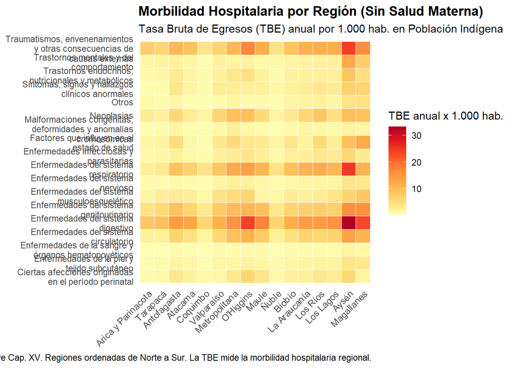

```r
# Chunk `regional` del pipeline: indicadores por region y heatmap
denominador_region <- preparar_denominador_estrato(censo_lista$por_region)
# Homologar tipo de la llave con la de datos_analisis (integer)
denominador_region$region <- as.integer(denominador_region$region)

# Guardas previas con mensaje claro (fallar rapido y explicito)
stopifnot(
  all(c("PERTENENCIA2", "COND_EGR", "DIAS_ESTADA", "Capitulo", "region") %in%
        names(datos_analisis)),
  all(c("grupo", "poblacion", "region") %in% names(denominador_region)),
  typeof(datos_analisis$region) == typeof(denominador_region$region)
)

ind_region <- calcular_indicadores_estratificados(
  datos = datos_analisis,
  denominador_df = denominador_region,
  var_estrato = "region"
)

# Verificacion de cobertura: 16 regiones x grupo, sin TBE perdida en PI
stopifnot(
  length(unique(ind_region$region[ind_region$grupo == "PI"])) == 16L,
  !any(is.na(ind_region$TBE[ind_region$grupo == "PI"]))
)

p_heatmap_region <- graficar_heatmap_regional(
  ind_region, "Morbilidad Hospitalaria por Región (Sin Salud Materna)"
)
p_heatmap_region
```

```r
# Respaldo de la imagen vieja (sufijo _OLD junto a ella) y exportacion al
# MISMO path del pipeline. Workaround JPEG: PNG + magick (ver nota inicial)
stopifnot(file.exists(ruta_figura))
ok_copia <- file.copy(ruta_figura, ruta_respaldo, overwrite = TRUE)
stopifnot(ok_copia)
cat("Respaldo imagen vieja en:", ruta_respaldo, "\n")
```

```
Respaldo imagen vieja en: D:/MAGISTER/aa TESIS/rtsppoo/DOCUMENTOS TESIS/FINAL-TESIS/figuras_nuevas/salida/figura_2_6_heatmap_regional_tbe_sin_op_OLD.jpg
```

```r
if (requireNamespace("magick", quietly = TRUE)) {
  ruta_png <- tempfile(fileext = ".png")
  ggsave(ruta_png, p_heatmap_region, width = 12, height = 8, dpi = 300,
         bg = "white")
  img <- magick::image_read(ruta_png)
  magick::image_write(img, ruta_figura, format = "jpeg", quality = 95)
  cat("Figura exportada (PNG + magick q95):", ruta_figura, "\n")
} else {
  warning("Paquete magick no instalado: ggsave directo a JPEG ",
          "(riesgo de colores corruptos en este equipo).")
  ggsave(ruta_figura, p_heatmap_region, width = 12, height = 8, dpi = 300,
         bg = "white")
  cat("Figura exportada (ggsave directo):", ruta_figura, "\n")
}
```

```
Figura exportada (PNG + magick q95): D:/MAGISTER/aa TESIS/rtsppoo/DOCUMENTOS TESIS/FINAL-TESIS/figuras_nuevas/salida/figura_2_6_heatmap_regional_tbe_sin_op.jpg
```

```r
# CSV de trazabilidad: filas PI que alimentan el heatmap
fig12_pi <- ind_region %>%
  filter(grupo == "PI") %>%
  mutate(nombre_region = codigo_a_nombre_region(region, tipo = "corto")) %>%
  select(region, nombre_region, Capitulo, Ec, Et, TBE) %>%
  arrange(region, desc(TBE))
write.csv(fig12_pi, ruta_csv, row.names = FALSE, fileEncoding = "UTF-8")
cat("CSV trazabilidad en:", ruta_csv, "\n")
```

```
CSV trazabilidad en: D:/MAGISTER/aa TESIS/rtsppoo/resultados_tesis/perfiles/fig12_tbe_capitulo_region.csv
```

```r
# Contraste contra el artefacto viejo (suma de TBE por capitulo = TBE total PI)
old <- read.csv(ruta_old, fileEncoding = "UTF-8", stringsAsFactors = FALSE)
old_pi <- aggregate(TBE ~ region, data = old[old$grupo == "PI", ], FUN = sum)
new_pi <- aggregate(TBE ~ region, data = fig12_pi, FUN = sum)
comp <- merge(old_pi, new_pi, by = "region", suffixes = c("_vieja", "_nueva"))
comp$dif <- round(comp$TBE_nueva - comp$TBE_vieja, 2)
cat("TBE total PI por region (suma capitulos): vieja vs nueva\n")
```

```
TBE total PI por region (suma capitulos): vieja vs nueva
```

```r
print(comp)
```

```
   region TBE_vieja TBE_nueva dif
1       1  43.04964  43.04964   0
2       2  83.53432  83.53432   0
3       3  58.10494  58.10494   0
4       4  28.23687  28.23687   0
5       5  69.67021  69.67021   0
6       6 120.82080 120.82080   0
7       7  83.94947  83.94947   0
8       8  67.79987  67.79987   0
9       9  79.53507  79.53507   0
10     10  82.10237  82.10237   0
11     11 194.05516 194.05516   0
12     12 145.64111 145.64111   0
13     13 100.15572 100.15572   0
14     14  91.58711  91.58711   0
15     15  38.83551  38.83551   0
16     16  32.93703  32.93703   0
```

```r
# Liberacion de memoria
rm(datos_analisis, ind_region, censo_lista, denominador_region, fig12_pi,
   p_heatmap_region, old, old_pi, new_pi, comp)
gc(verbose = FALSE)
```

```
           used  (Mb) gc trigger   (Mb)  max used   (Mb)
Ncells  2023532 108.1    8364570  446.8  11016773  588.4
Vcells 12065137  92.1  548013919 4181.1 772951527 5897.2
```

```r
cat("Memoria liberada.\n")
```

```
Memoria liberada.
```